# Dehumanization X Columbus Day/Indigenous Peoples Day

Terrence Pope

2018-08-15

# Intro

This is a data set that includes the following variables:

| DH1_W_Responsible |
| --- |
| DH2_W_Civilized |
| DH3_W_Moral |
| DH4_W_Polite |
| DH5_W_Childlike |
| DH6_W_Rational |
| DH7_W_Warm |
| DH8_W_Agentic |
| DH9_W_Refined |
| DH10_W_Lacking_Culture |
| DH11_W_Lacking_Self-restraint |
| DH12_W_Instinctual |
| DH13_W_Mature |
| DH14_W_Stoic |
| DH15_W_Emotionally_Responsive |
| DH16_W_Cold |
| DH17_W_Open |
| DH18_W_Rigid |
| DH19_W_Passive |
| DH20_W_Superficial |
| DH1_N_Responsible |
| DH2_N_Civilized |
| DH3_N_Moral |
| DH4_N_Polite |
| DH5_N_Childlike |
| DH6_N_Rational |
| DH7_N_Warm |
| DH8_N_Agentic |
| DH9_N_Refined |
| DH10_N_Lacking_Culture |
| DH11_N_Lacking_Self-restraint |
| DH12_N_Instinctual |
| DH13_N_Mature |
| DH14_N_Stoic |
| DH15_N_Emotionally_Responsive |
| DH16_N_Cold |
| DH17_N_Open |
| DH18_N_Rigid |
| DH19_N_Passive |
| DH20_N_Superficial |
| No_Columbus |
| Create_IPD |
| BorninUS |
| LengthState |
| FatherUSBorn |
| MotherUSBorn |
| PrimaryCaretaker |
| PrimaryEd |
| SecondCaretaker |
| SecondEdu |
| Religion |
| Religiosity |
| College |
| Year |
| Education |
| LibCon |
| SES |
| Race |
| StateNumeric |
| LongestRegion |
| SubjectNumber |
| White_Dehumanize |
| Native_Dehumanize |
| Age |

It’s primary focus is to look a bit more closely at the dehumaniztion variables and how they interact not only with one another, but with the dependent variables (Columbus Day/Indigenous Peoples’ Day (henceforth referred to as IPD)), as well as some of the demographic information gathered on the participants in this sample.

This sample comes from **Study Two**, so it is (*if I’m not mistaken*) a sample of participants gathered via *mturk*.

# Descriptives

First, lets take a look at a descriptives table of our variables. Keep in mind that some of the variables are categorical and are more difficult to interpret in a descriptives table.

|  | n | mean | sd | median | se |
| --- | --- | --- | --- | --- | --- |
| **DH1_W_Responsible** | 2811 | 61.24 | 21.82 | 62 | 0.4116 |
| **DH2_W_Civilized** | 2810 | 65.89 | 23.38 | 69 | 0.4411 |
| **DH3_W_Moral** | 2812 | 55.77 | 22.76 | 55 | 0.4292 |
| **DH4_W_Polite** | 2812 | 57.99 | 22.53 | 58 | 0.4248 |
| **DH5_W_Childlike** | 2809 | 40.76 | 24.49 | 43 | 0.462 |
| **DH6_W_Rational** | 2810 | 58.23 | 22.49 | 57 | 0.4243 |
| **DH7_W_Warm** | 2810 | 58.27 | 22.32 | 58 | 0.421 |
| **DH8_W_Agentic** | 2800 | 46.11 | 22.34 | 50 | 0.4222 |
| **DH9_W_Refined** | 2809 | 52.87 | 22.26 | 52 | 0.4199 |
| **DH10_W_Lacking_Culture** | 2808 | 46.34 | 27.71 | 50 | 0.523 |
| **DH11_W_Lacking_Self-restraint** | 2808 | 48.59 | 25.58 | 50 | 0.4828 |
| **DH12_W_Instinctual** | 2810 | 51.47 | 22.98 | 51 | 0.4335 |
| **DH13_W_Mature** | 2809 | 57.34 | 22.31 | 56 | 0.421 |
| **DH14_W_Stoic** | 2808 | 42.88 | 22.31 | 49 | 0.4209 |
| **DH15_W_Emotionally_Responsive** | 2812 | 59.98 | 22.77 | 60 | 0.4294 |
| **DH16_W_Cold** | 2810 | 44.74 | 23.99 | 49 | 0.4525 |
| **DH17_W_Open** | 2811 | 55.59 | 22.81 | 55 | 0.4302 |
| **DH18_W_Rigid** | 2807 | 49.6 | 23.27 | 50 | 0.4393 |
| **DH19_W_Passive** | 2810 | 45.16 | 23.21 | 49 | 0.4378 |
| **DH20_W_Superficial** | 2810 | 59.32 | 25.54 | 60 | 0.4818 |
| **DH1_N_Responsible** | 2807 | 63.86 | 21.06 | 64 | 0.3976 |
| **DH2_N_Civilized** | 2806 | 64.58 | 21.97 | 65 | 0.4147 |
| **DH3_N_Moral** | 2807 | 65.75 | 20.88 | 66 | 0.3941 |
| **DH4_N_Polite** | 2806 | 63.22 | 21.42 | 63 | 0.4044 |
| **DH5_N_Childlike** | 2802 | 29.22 | 22.26 | 25 | 0.4205 |
| **DH6_N_Rational** | 2807 | 61.61 | 21.17 | 61 | 0.3995 |
| **DH7_N_Warm** | 2804 | 61.05 | 22.07 | 60 | 0.4167 |
| **DH8_N_Agentic** | 2800 | 44.97 | 22.32 | 50 | 0.4219 |
| **DH9_N_Refined** | 2806 | 51.11 | 22.44 | 51 | 0.4235 |
| **DH10_N_Lacking_Culture** | 2804 | 23.9 | 23.15 | 17 | 0.4371 |
| **DH11_N_Lacking_Self-restraint** | 2805 | 34.44 | 23.39 | 33 | 0.4416 |
| **DH12_N_Instinctual** | 2807 | 61.3 | 23.48 | 61 | 0.4433 |
| **DH13_N_Mature** | 2806 | 65.15 | 20.69 | 65 | 0.3907 |
| **DH14_N_Stoic** | 2808 | 59.11 | 22.29 | 57 | 0.4206 |
| **DH15_N_Emotionally_Responsive** | 2806 | 54.38 | 24.29 | 53 | 0.4585 |
| **DH16_N_Cold** | 2805 | 35.19 | 22.8 | 35 | 0.4306 |
| **DH17_N_Open** | 2805 | 53.8 | 23.34 | 53 | 0.4406 |
| **DH18_N_Rigid** | 2807 | 45.41 | 23.89 | 50 | 0.451 |
| **DH19_N_Passive** | 2805 | 45.03 | 23.79 | 50 | 0.4492 |
| **DH20_N_Superficial** | 2805 | 30.41 | 22.87 | 27 | 0.4318 |
| **No_Columbus** | 2858 | 3.793 | 2.125 | 4 | 0.03976 |
| **Create_IPD** | 2858 | 4.481 | 1.956 | 4 | 0.03658 |
| **BorninUS*** | 2801 | 1.956 | 0.2041 | 2 | 0.003857 |
| **LengthState** | 2797 | 30.72 | 12.88 | 29 | 0.2435 |
| **FatherUSBorn*** | 2801 | 1.893 | 0.3352 | 2 | 0.006334 |
| **MotherUSBorn*** | 2801 | 1.882 | 0.3337 | 2 | 0.006306 |
| **PrimaryCaretaker*** | 2800 | 1.282 | 0.7601 | 1 | 0.01436 |
| **PrimaryEd** | 2801 | 2.988 | 1.225 | 3 | 0.02315 |
| **SecondCaretaker*** | 2801 | 2.828 | 1.114 | 3 | 0.02105 |
| **SecondEdu** | 2736 | 2.908 | 1.323 | 2 | 0.02529 |
| **Religion*** | 2799 | 2.45 | 1.674 | 2 | 0.03164 |
| **Religiosity** | 2800 | 3.632 | 2.235 | 4 | 0.04224 |
| **College*** | 2799 | 1.893 | 0.3094 | 2 | 0.005848 |
| **Year** | 300 | 3.363 | 1.631 | 3 | 0.09417 |
| **Education** | 2800 | 3.459 | 1.127 | 4 | 0.0213 |
| **LibCon** | 2799 | 4.401 | 1.713 | 4 | 0.03237 |
| **SES*** | 2801 | 1.538 | 0.4986 | 2 | 0.009422 |
| **Race*** | 2903 | 3.42 | 1.684 | 3 | 0.03125 |
| **StateNumeric*** | 2788 | 24.73 | 14.36 | 25 | 0.272 |
| **LongestRegion*** | 2789 | 4.425 | 2.104 | 5 | 0.03984 |
| **SubjectNumber** | 2903 | 1452 | 838.2 | 1452 | 15.56 |
| **White_Dehumanize** | 2793 | 52.93 | 12.03 | 53.25 | 0.2275 |
| **Native_Dehumanize** | 2792 | 50.67 | 11.38 | 51.05 | 0.2153 |
| **Age** | 2793 | 38.72 | 13.33 | 35 | 0.2523 |

## Correlation of Dehumanization

One thing you’ll probably notice right away is that I’ve made some aggregate variables at the end of the data set that average across all Dehumanization measures for both whites and natives. Let’s take a look at the relationship between the two zoomed out a bit.

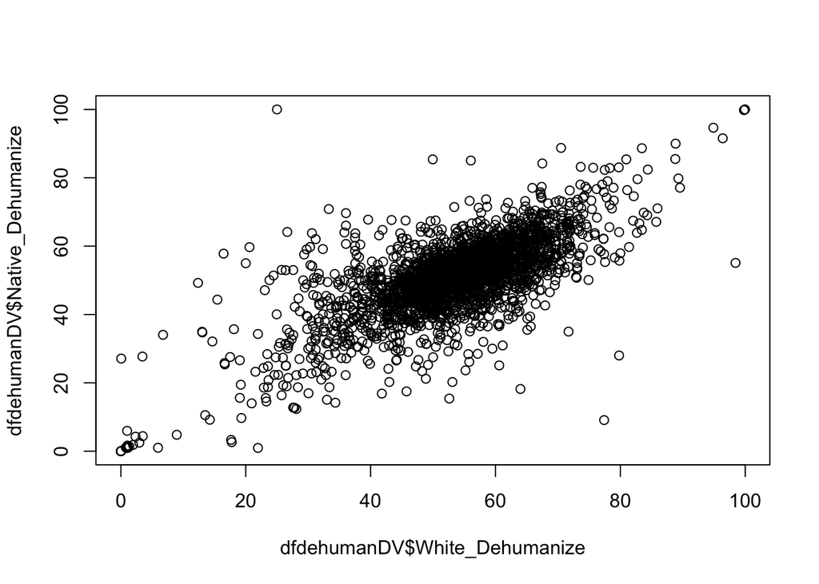

```
##
##  Pearson's product-moment correlation
##
## data:  dfdehumanDV$White_Dehumanize and dfdehumanDV$Native_Dehumanize
## t = 55.589, df = 2784, p-value < 2.2e-16
## alternative hypothesis: true correlation is not equal to 0
## 95 percent confidence interval:
##  0.7072142 0.7424398
## sample estimates:
##       cor
## 0.7253014
```

At baseline the two seem to hang together pretty well. People seem to be rating Natives and Whites similarly among the measures of dehumanization that we have.

## Dependent Variables: Columbus Day X Dehumanization

Before we move on, let’s take a gander at the dependent variables. Does there seem to be a relationship between dehumanization and *Support for getting rid of Columbus Day*?

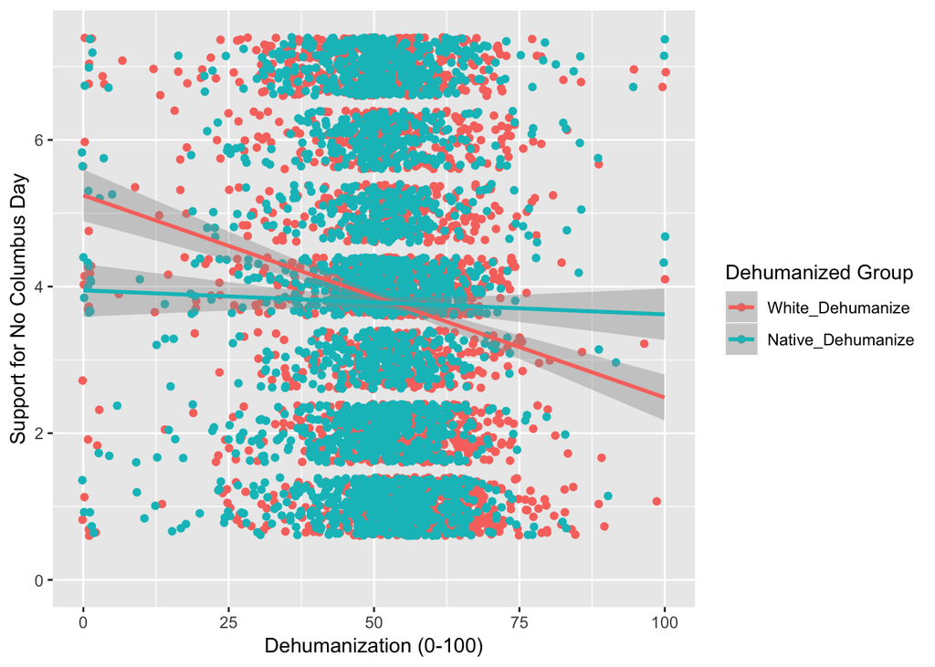

```
##
## Call:
## lm(formula = No_Columbus ~ Rating + Group + Rating:Group, data = dv4cor.lng)
##
## Residuals:
##     Min      1Q  Median      3Q     Max
## -4.2443 -1.7991  0.1583  2.1348  4.5126
##
## Coefficients:
##                                Estimate Std. Error t value Pr(>|t|)
## (Intercept)                    5.244311   0.180457  29.061  < 2e-16 ***
## Rating                        -0.027582   0.003325  -8.296  < 2e-16 ***
## GroupNative_Dehumanize        -1.296491   0.256706  -5.050 4.55e-07 ***
## Rating:GroupNative_Dehumanize  0.024315   0.004839   5.025 5.19e-07 ***
## ---
## Signif. codes:  0 '***' 0.001 '**' 0.01 '*' 0.05 '.' 0.1 ' ' 1
##
## Residual standard error: 2.113 on 5581 degrees of freedom
##   (221 observations deleted due to missingness)
## Multiple R-squared:  0.01233,    Adjusted R-squared:  0.0118
## F-statistic: 23.23 on 3 and 5581 DF,  p-value: 6.143e-15
```

`**Keep in mind while looking at this graph that low scores on the dehumanization measure mean that participants are dehumanizing the group` **more**.

## Dependent Variables: Indigenous Peoples’ Day X Dehumanization

What about between dehumanization and *Support for IPD*?

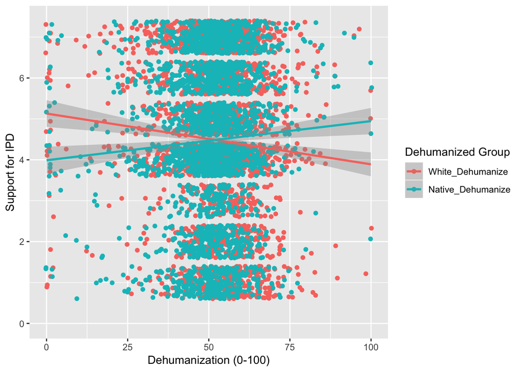

```
##
## Call:
## lm(formula = Create_IPD ~ Rating + Group + Rating:Group, data = dv5cor.lng)
##
## Residuals:
##     Min      1Q  Median      3Q     Max
## -4.1305 -1.3811 -0.2253  1.5698  3.0665
##
## Coefficients:
##                                Estimate Std. Error t value Pr(>|t|)
## (Intercept)                    5.130533   0.166784  30.762  < 2e-16 ***
## Rating                        -0.012417   0.003073  -4.041 5.40e-05 ***
## GroupNative_Dehumanize        -1.142140   0.237256  -4.814 1.52e-06 ***
## Rating:GroupNative_Dehumanize  0.021991   0.004472   4.917 9.03e-07 ***
## ---
## Signif. codes:  0 '***' 0.001 '**' 0.01 '*' 0.05 '.' 0.1 ' ' 1
##
## Residual standard error: 1.953 on 5581 degrees of freedom
##   (221 observations deleted due to missingness)
## Multiple R-squared:  0.004461,   Adjusted R-squared:  0.003926
## F-statistic: 8.337 on 3 and 5581 DF,  p-value: 1.577e-05
```

## Dependent Variables: Side by Sides

We can also look at both of these groups side by side:

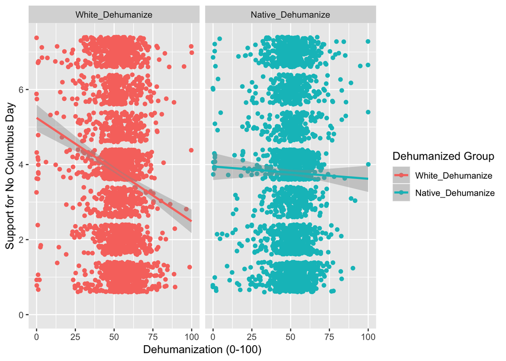

and…

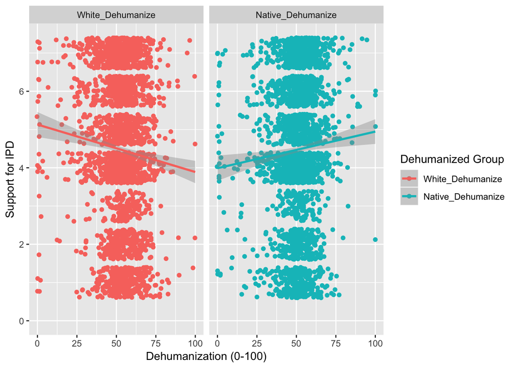

## Dependent Variables: Digging a Little Deeper

Whe can see more clearly that significant interaction when they are side by side. Attitudes toward white more strongly predicts the relationship between dehumanization and support for removing Columbus day.

Interestingly, the direction of that relationship changes when we’re talking about IPD. If we create a model that looks at this interaction with both ratings of support and dehumanization centered at the mean we see that this change in direction is significant (*p* = .005)

```
##
## Call:
## lm(formula = Native_Dehumanize ~ Rating + Holiday_Support + Rating:Holiday_Support,
##     data = dv4and5cor.lng.cen)
##
## Residuals:
##     Min      1Q  Median      3Q     Max
## -51.489  -4.395   0.429   5.979  50.128
##
## Coefficients:
##                                   Estimate Std. Error t value Pr(>|t|)
## (Intercept)                       -0.10887    0.21830  -0.499  0.61799
## Rating                             0.32336    0.10994   2.941  0.00328 **
## Holiday_SupportNo_Columbus         0.07569    0.30859   0.245  0.80626
## Rating:Holiday_SupportNo_Columbus -0.41695    0.14945  -2.790  0.00529 **
## ---
## Signif. codes:  0 '***' 0.001 '**' 0.01 '*' 0.05 '.' 0.1 ' ' 1
##
## Residual standard error: 11.37 on 5580 degrees of freedom
##   (222 observations deleted due to missingness)
## Multiple R-squared:  0.001701,   Adjusted R-squared:  0.001164
## F-statistic: 3.169 on 3 and 5580 DF,  p-value: 0.02334
```

`**For some reason in the markdown document the "Rating" coefficient is significant. In the code it is not` (*p*=.12).

# Exploratory Analysis

Let’s dig into some of the demographic information in this subset of the data.

## Race

First let’s look at the frequency of our different racial groups

| Asian | Black | White | Latino | Middle Eastern | Native | Other | Multiracial |
| --- | --- | --- | --- | --- | --- | --- | --- |
| 139 | 224 | 2097 | 106 | 4 | 17 | 24 | 292 |

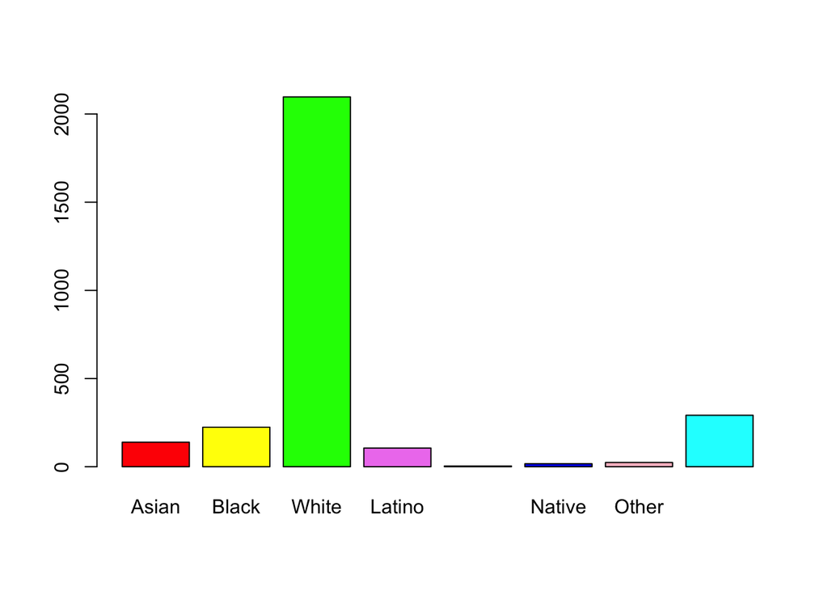

```r
# ggplot(Data.lng.c2, aes(x=Condition, y=Rating, fill=Race)) +
#   geom_bar(position=position_dodge(), stat="identity",
#            colour="black", # Use black outlines,
#            size=.3) +      # Thinner lines
#   geom_errorbar(aes(ymin=Rating-se, ymax=Rating+se),
#                 size=.3,    # Thinner lines
#                 width=.2,
#                 position=position_dodge(.9)) +
#   xlab("Participant Condition") +
#   ylab("Participant Ratings (1-7)") +
#   scale_fill_hue(name="Applicant Race", # Legend label, use darker colors
#                  breaks=c("AF", "AA"),
#                  labels=c("African American", "Asian American")) +
#   ggtitle("Ratings of Applicants on Measures of\nAmericanness, Qualification, and Status") +
#   scale_y_continuous(limits = c(0,7)) +
#   facet_wrap(~Measure) +
#   theme_bw()

# ggplot(data = gapminder, aes(x = year, y = lifeExp, group = country)) +
#   geom_line(alpha = 0.5, aes(color = "Country", size = "Country")) +
#   geom_line(stat = "smooth", method = "loess",
#             aes(group = continent, color = "Continent",
#                 size = "Continent"), alpha = 0.5) +
#   xlab("Year") +
#   ylab("Life Expectancy") +
#   facet_wrap(~ continent, nrow = 2) +
#   scale_color_manual(name = "Unit", values = c("Country" = "black",
#                                                "Continent" = "blue")) +             scale_size_manual(name = "Unit", values = c("Country" = 0.5,
#                                               "Continent" = 3)) +
#   theme_minimal(base_size = 14) +
#   theme(legend.position=c(0.75, 0.2),
#         axis.text.x = element_text(angle = 45))
```